# Setting up Git and GitHub

David Gerard

2023-08-05

# Learning Objectives

- Installing git
- Setting up GitHub
- [Connecting to GitHub with SSH](https://docs.github.com/en/authentication/connecting-to-github-with-ssh)

# Installing Git

1. Install git:
   - Windows: http://git-scm.com/download/win.
   - OS X: http://git-scm.com/download/mac.
   - Debian/Ubuntu: `sudo apt-get install git-core`.
   - Other Linux distros: http://git-scm.com/download/linux.
2. Create an account on GitHub: https://github.com/
   - A free plan is fine. Use the same email address you used above.
   - When you choose your username, remember that you might use this for professional purposes. So I would recommend something related to your name (e.g. my handle is “dcgerard”). I would recommend against something like “david_awesome_david_yolo_hahaha”.
3. Tell git your name and email address. Open up a terminal and type:

   ```bash
   git config --global user.name "YOUR FULL NAME"
   git config --global user.email "YOUR EMAIL ADDRESS"
   ```

   If you are worried about email privacy, then use “<username>@users.noreply.github.com” as your email address (where you have replaced <username> with your GitHub username), then follow the instructions [here](https://help.github.com/en/articles/setting-your-commit-email-address-on-github) to make your email address private on GitHub.
4. Choose your favorite editor to be your default
   - Nano (a simple text editor):

     ```bash
     git config --global core.editor "nano -w"
     ```

   - Notepad (Windows only):

     ```bash
     git config --global core.editor "c:/Windows/System32/notepad.exe"
     ```

   - Emacs (for the brave) if it is already installed:

     ```bash
     git config --global core.editor "emacs"
     ```

# Authentication

- To integrate GitHub (the website) with git (the command-line program), you have to set up the proper authorization.
- If you can already integrate with GitHub through the command line then you can skip the rest of these notes. If you are not sure, then please continue.
- GitHub now requires you to use either [Personal Access Tokens](https://docs.github.com/en/authentication/keeping-your-account-and-data-secure/creating-a-personal-access-token) or [SSH Keys](https://docs.github.com/en/authentication/connecting-to-github-with-ssh) for interfacing. For this class, we’ll use SSH Keys since its implementation is slightly easier.
- An alternative setup using personal access tokens can be found [here](https://usethis.r-lib.org/articles/git-credentials.html).
- SSH uses what’s called a [key pair](https://en.wikipedia.org/wiki/Public-key_cryptography) where GitHub has a “public key” (a very long publicly known password) and you have on your computer a “private key” (a very long privately known password).
- Think about the public key as a padlock, and the private key as the key. You have to use to private key to unlock the public key.
- You need to generate a new private key, and go through the below steps, for each computer for which you intend to use git.

## Generate Key Pair on R Studio

- R Studio makes it easy to generate a key pair.
- Check to see if you already have an SSH key pair by running the following in R

  ```r
  file.exists("~/.ssh/id_rsa.pub")
  ```

  It will return `FALSE` if you do not have a key pair.
- Open up Tools > Global Options… > Git/SVN.
- If you do not have an SSH key pair, then click on “Create SSH Key…” and follow the prompts.

[figure not shown]

- Click on “View public key”

[figure not shown]

- Copy the entire text that shows up. This is your public key.
- Go to Add Public Key to GitHub to continue authentication setup.

## Generate Key Pair on the Terminal

- If the R Studio pipeline does not work, then try generating your key pair on the terminal with the following instructions.

### Check for existing SSH Keys

- In the terminal run

  ```bash
  ls -al ~/.ssh
  ```

- This will say something like “ls: cannot access ‘/c/Users/Vlad Dracula/.ssh’: No such file or directory” if you don’t have any public/private key pairs.
- This will list out files names like “id_rsa.pub”, “id_ecdsa.pub”, or “id_ed25519.pub” if you do have a public/private key pair.

### Generate a new SSH key

- If you **do** have an SSH key, go to the next section (“Add an SSH key to the ssh-agent”)
- If you **don’t** have an SSH key, follow the below steps.
- In the terminal, run

  ```bash
  ssh-keygen -t ed25519 -C "your_email@example.com"
  ```

- Press enter if prompted where to save the key to accept the default location.
- At the prompt, type a password that you can remember.

### Add an SSH key to the ssh-agent

1. In the terminal, run the following to start the ssh-agent in the background.

   ```bash
   eval "$(ssh-agent -s)"
   ```

2. In the terminal, run the following to add your SSH private key to the ssh-agent:

   ```bash
   ssh-add ~/.ssh/id_ed25519
   ```

### Copy Public Key

1. Run the following in the terminal to show the contents of “id_ed25519.pub”.

   ```bash
   cat ~/.ssh/id_ed25519.pub
   ```

2. Highlight the output using your mouse and copy the contents.

## Add Public Key to GitHub

1. On [GitHub](https://github.com/settings/keys), in the upper right corner, click on your profile photo and click on “Settings”

[figure not shown]

2. On the left sidebar, click on “SSH and GPG keys”

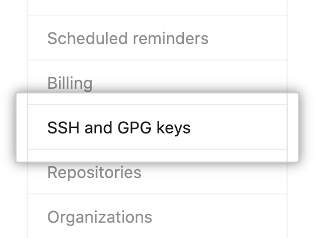

3. Click on “New SSH key”

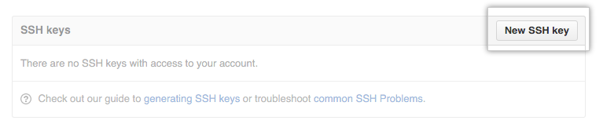

4. In the title field, choose a descriptive title, like “Personal Laptop”.
5. Paste your key into the “Key” field.
6. Click “Add SSH key” and confirm your GitHub password.

## Test to see if it worked

1. Enter the following in the terminal:

   ```bash
   ssh -T git@github.com
   ```

2. Type “yes” if prompted to continue connecting.
3. You are successful if you see something like

   ```
   Hi dcgerard! You've successfully authenticated, but GitHub does not provide shell access.
   ```